# Krycklan soil survey data

Johannes Larson

14/09/2022

# The Krycklan Survey

## Soil survey

Most of them are self explanatory but here is a table with descriptions for those that are not:

| Variable | Description |
| --- | --- |
| Plot | Plot number |
| Date | Date of soil sampling |
| SMC | Soil moisture code |
| OTh_plot | Mean OLT (cm) from 12 measurements (3 measurements in N,S,W and East). Measured to max 99 cm |
| OTh_plot | Mean OLT (cm) from measurements within pit circle (radius=1m). Measured to max 99 cm |
| Soil Type | WRB system |
| DTW1_1m | Depth to water 1ha 1m resolution |
| TWI_16m | Topographic wetness index 16m resolution |
| DI2_2m | Downslope index 2m threshold 2m resolution |
| EAS1_1m | Elevation above stream 1 ha and 1m resolution |
| Plfc | Pennocks landform class |
| Plan_C | Plan curvature |
| WILT | Wetness index based on landscape position and topography |
| SLU_Markfu | 1-100% SLU soil moisture map |
| SLU_Klassad | SLU soil moisture map (Classed) |
| FA2m | Flow accumulation 2m resolution |

## Soil sample chemistry data

Samples were taken at fixed depths at each soil survey plot. Mineral soil samples were taken at 0-10, 10-20 and 55-65 cm depths. Organic layer and mineral soil samples have been analysed using IRMSR mass spectromety for Carbon and Nitrogen content. SampleDepth column is used to separate from samples (0=organic layer).

Terrain indices have been included in this dataset also but below you find the chemistry variables explained:

| Variable | Description |
| --- | --- |
| Plot | Plot number |
| SampleDepth | 0= Organic layer, 10 = Mineral soil sample between 0-10cm depth, 20 = 10-20 cm, 65= 55-65cm |
| cN | Total Nitrogen content (N%) |
| cC | Total Carbon content (C%) |

The soil survey grid cover the entire landscape off Krycklan, here illustrated by the C% in the organic layer samples

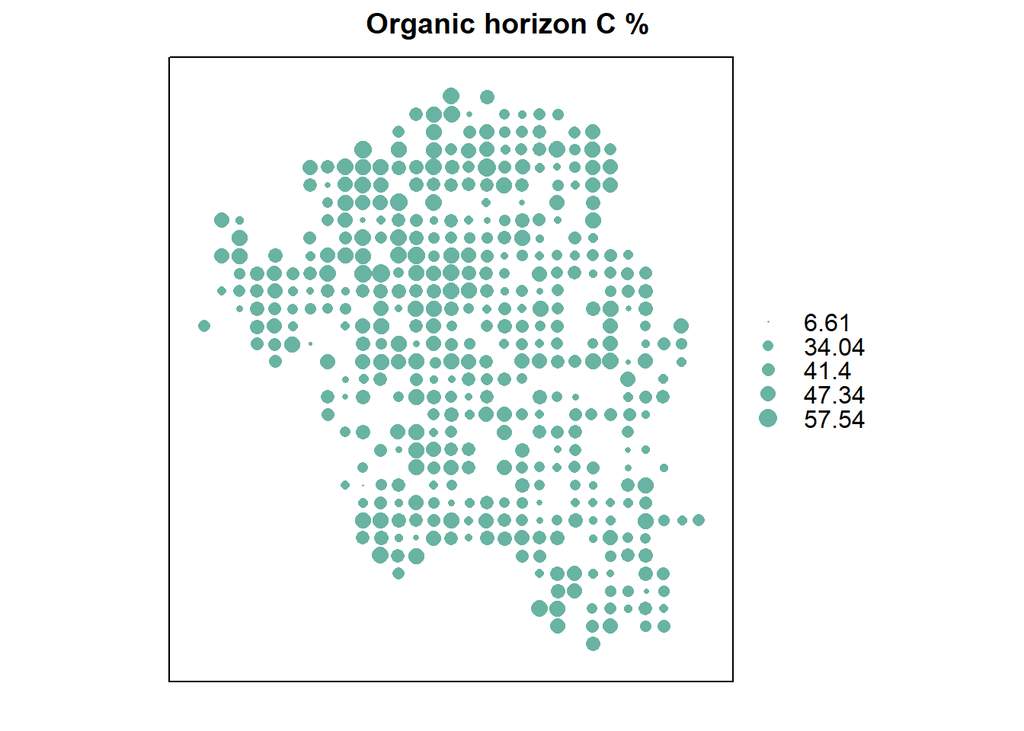